RH Exemple

**Exercices 2008 à 2012**

Fabrice Nicol

mar. 04 nov. 2014

# 1. Statistiques de population

### 1.1 Effectifs

|  | 2008 | 2009 | 2010 | 2011 | 2012 |
| --- | --- | --- | --- | --- | --- |
| Total effectifs | 1 119,000 | 1 146,000 | 1 221,000 | 1 215,000 | 1 260,000 |
| dont présents 12 mois | 870,000 | 953,000 | 922,000 | 991,000 | 1 037,000 |
| dont fonctionnaires | 704,000 | 706,000 | 733,000 | 735,000 | 744,000 |
| dont fonct. présents 12 mois | 644,000 | 661,000 | 667,000 | 698,000 | 690,000 |
| dont élus | 100,000 | 72,000 | 75,000 | 73,000 | 76,000 |
| dont élus présents 12 mois | 37,000 | 67,000 | 69,000 | 72,000 | 71,000 |
| Total ETP/année | 1 116,077 | 1 177,518 | 1 234,585 | 1 206,572 | 1 216,105 |

Lien vers la base des effectifs

### 1.2 Pyramide des âges, personnels non élus

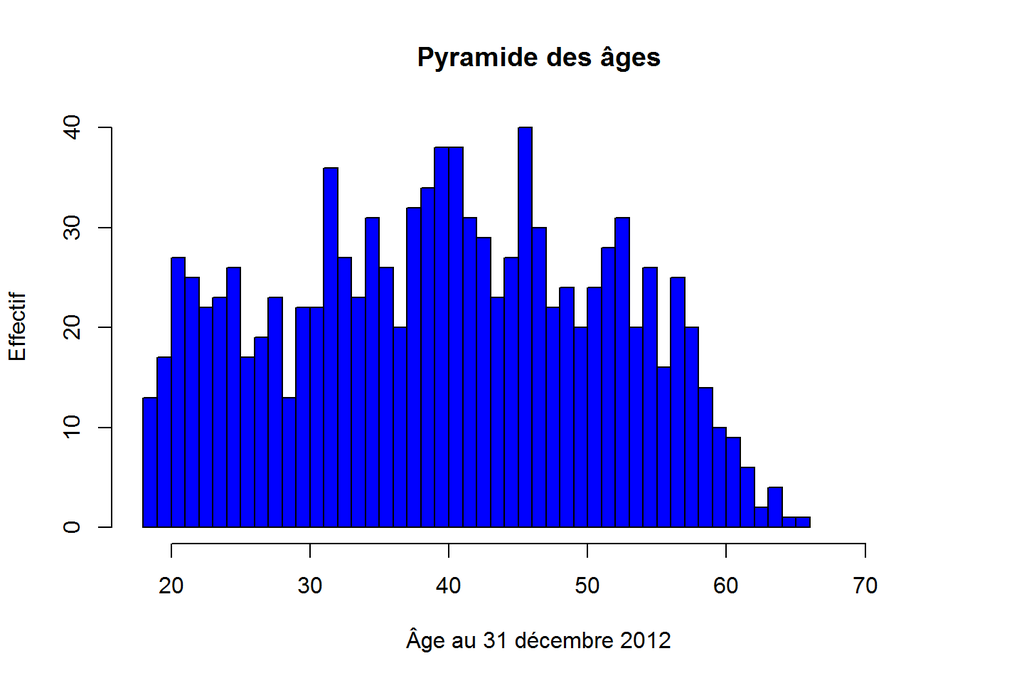

Lien vers la base des âges

| Statistique | Âge des personnels au 31/12/2012 | Effectif |
| --- | --- | --- |
| Minimum | 18 |  |
| 1er quartile | 31 |  |
| Médiane | 40 |  |
| Moyenne | 40,08 |  |
| 3ème quartile | 49 |  |
| Maximum | 66 |  |

### 1.3 Pyramide des âges, personnels fonctionnaires stagiaires et titulaires

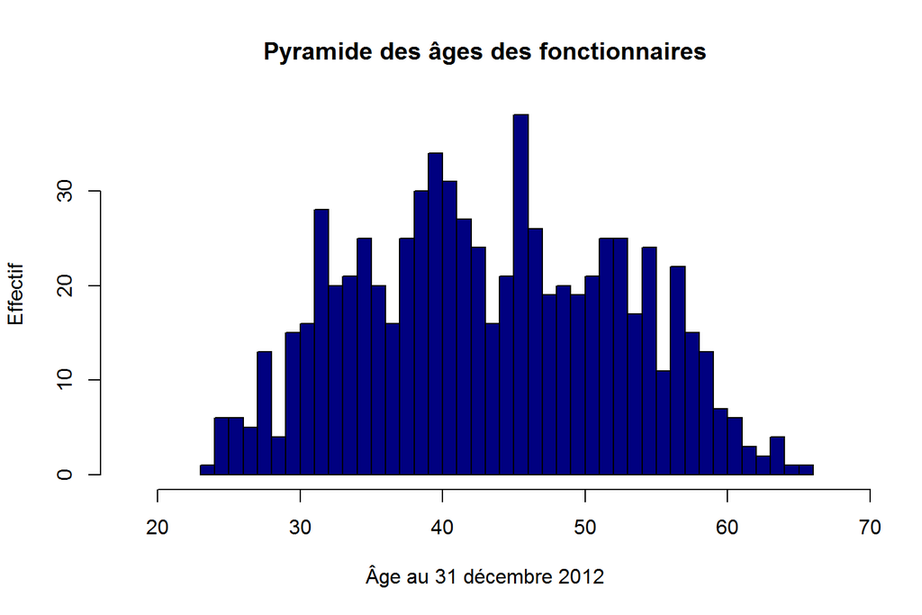

Lien vers la base des âges

| Statistique | Âge des personnels au 31/12/2012 | Effectif |
| --- | --- | --- |
| Minimum | 23 |  |
| 1er quartile | 37 |  |
| Médiane | 43 |  |
| Moyenne | 43,78 | 723 |
| 3ème quartile | 51 |  |
| Maximum | 66 |  |

### 1.4 Effectifs des personnels par durée de service

**Personnels en fonction des exercices 2008 à 2012 inclus :**

| Plus de 2 ans | Moins de 2 ans | Moins d’un an | Moins de six mois |
| --- | --- | --- | --- |
| 1 145 | 475 | 284 | 176 |

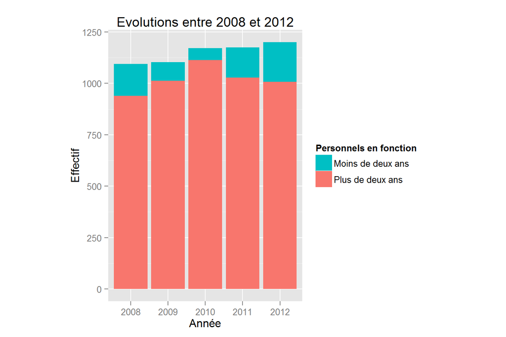

#### Effectifs

|  | 2008 | 2009 | 2010 | 2011 | 2012 |
| --- | --- | --- | --- | --- | --- |
| Plus de deux ans | 939 | 1 013 | 1 114 | 1 028 | 1 007 |
| Moins de deux ans | 155 | 90 | 58 | 147 | 193 |
| Total | 1 094 | 1 103 | 1 172 | 1 175 | 1 200 |

**Nota:** Personnels en place : ayant servi au moins 730 jours pendant la période. Dans les statistiques de cette section, les élus ne sont pas pris en compte.

# 2. Rémunérations brutes : analyse pour l’exercice 2008

## 2.1 Statistiques de position globales

### Cumuls des rémunérations brutes pour l’exercice 2008

*Personnels*

| Agrégats | euros |
| --- | --- |
| Brut annuel (bulletins) | 23 318 144 |
| Brut annuel (lignes), dont : | 23 365 224 |
| Indemnités imposables : | 5 950 613 |
| Autres rémunérations | 797 |

*Elus*

| Agrégats | euros |
| --- | --- |
| Brut annuel (bulletins) | 605 002 |
| Brut annuel (lignes), dont : | 709 254 |
| Indemnités imposables : | -51 256 |
| Autres rémunérations | 0 |

**Définitions :**

*Brut annuel (bulletins)* : somme du champ *Brut*  
*Brut annuel (lignes)* : somme du champ *Montant* des lignes de paye, dont :  
*Indemnités imposables* : indemnités sauf remboursements, certaines IJSS, indemnités d’élu  
*Indemnités d’élu* : toutes rémunérations indemnitaires des élus  
*Autres rémunérations* : acomptes, retenues sur brut, rémunérations diverses, rappels

**Tests de cohérence**

Somme des rémunérations brutes versées aux personnels (non élus) :

| Agrégats | euros |
| --- | --- |
| Bulletins de paie (euros) | 23 318 144 |
| Lignes de paie (euros) | 23 365 224 |
| Différence (euros) | -47 079 |

à comparer aux soldes des comptes 641 et 648 du compte de gestion.

Somme des rémunérations brutes versées (élus) :

| Agrégats | euros |
| --- | --- |
| Bulletins de paie (euros) | 605 002 |
| Lignes de paie (euros) | 709 254 |
| Différence (euros) | -104 252 |

Les résultats sont exprimés en euros.

## 2.2 Fonctionnaires titulaires et stagiaires

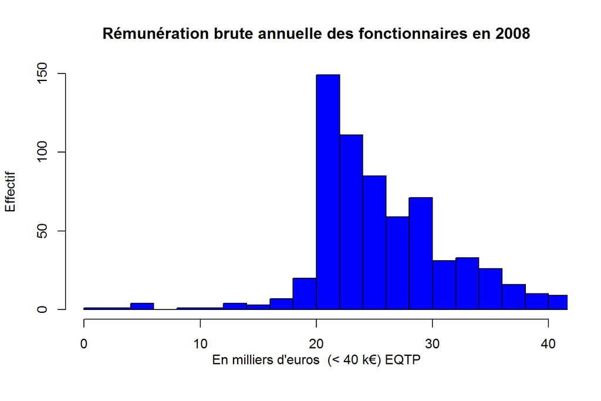

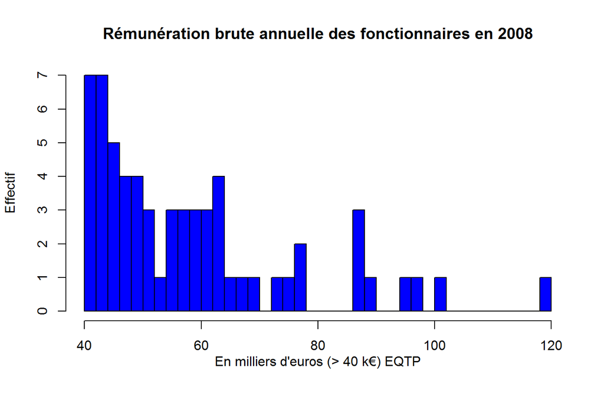

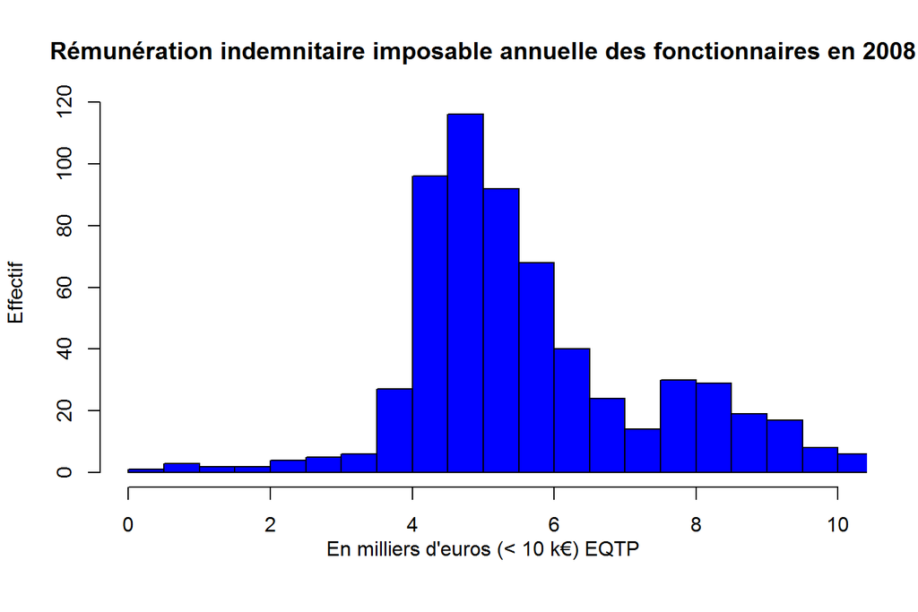

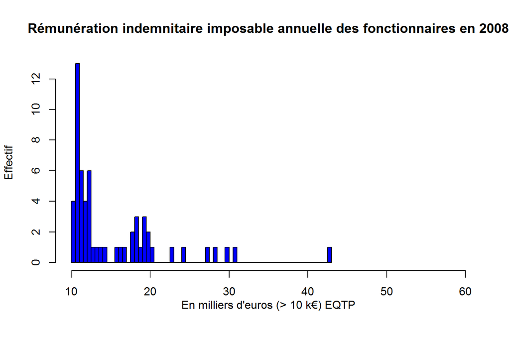

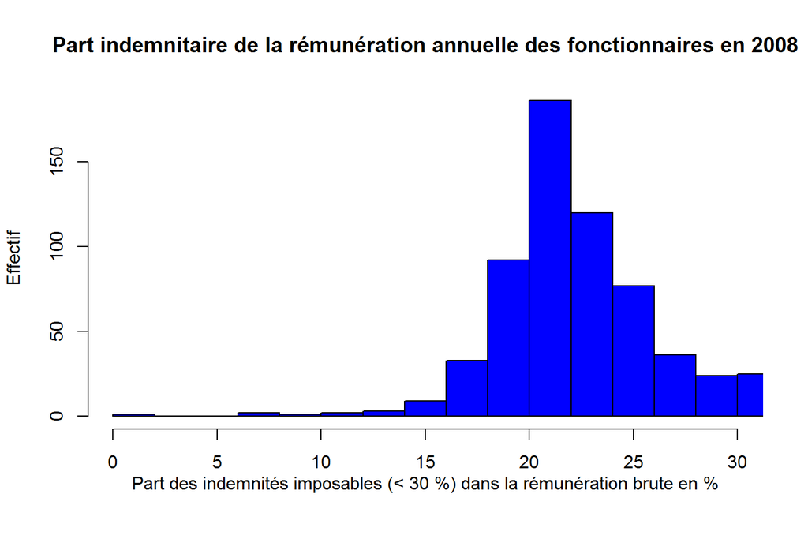

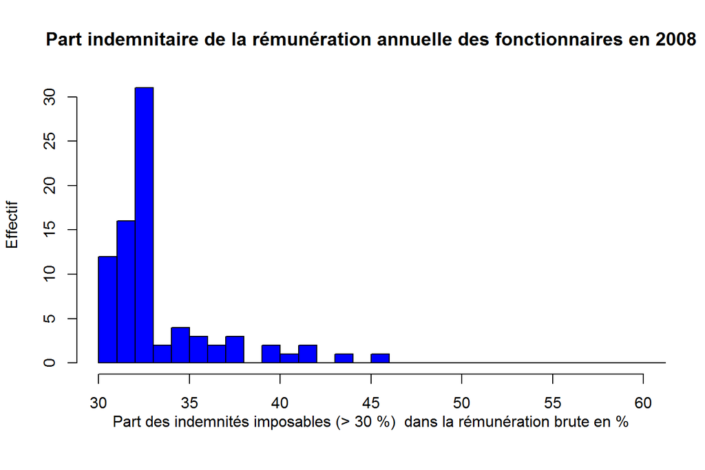

**Effectif : 693**

**Tests de cohérence**

Somme des rémunérations brutes versées aux personnels titulaires et stagiaires :

| Agrégats | euros |
| --- | --- |
| Brut annuel (bulletins) | 18 267 594 |
| Brut annuel (lignes), dont : | 18 388 645 |
| Indemnités imposables : | 4 536 736 |
| Autres rémunérations | 0 |

**Définitions :**

*Brut annuel (bulletins)* : somme du champ *Brut* *Brut annuel (lignes)* : somme du champ *Montant* des lignes de paye, dont :  
*Indemnités imposables* : champ *Brut* moins le SFT, le traitement indiciaire et l’indemnité de résidence *Indemnités d’élus* : toutes rémunérations indemnitaires des élus  
*Autres rémunérations* : acomptes, retenues sur brut, rémunérations diverses, rappels

**Tests de cohérence**

Somme des rémunérations brutes versées aux personnels (non élus) :

| Agrégats | euros |
| --- | --- |
| Bulletins de paie (euros) | 18 267 594 |
| Lignes de paie (euros) | 18 388 645 |
| Différence (euros) | -121 050 |

A comparer aux soldes des comptes 6411, 6419 et 648 du conmpte de gestion.

### Statistiques de position pour l’exercice 2008

| Statistique | Traitement indiciaire | Indemnités imposables | Autres rémunérations | Effectif |
| --- | --- | --- | --- | --- |
| Minimum | 0 | 0 | 0 |  |
| 1er quartile | 16 160 | 4 433 | 0 |  |
| Médiane | 17 808 | 5 345 | 0 |  |
| Moyenne | 19 363 | 6 547 | 0 | 693 |
| 3ème quartile | 22 354 | 7 617 | 0 |  |
| Maximum | 80 378 | 41 382 | 0 |  |

| Statistique | Total lignes hors rappels | Total brut | Total brut EQTP | Part de la rém. indemnitaire | Effectif |
| --- | --- | --- | --- | --- | --- |
| Minimum | 65,96 | 65,96 | 776,6 | 1,281 |  |
| 1er quartile | 21 387,98 | 21 298,62 | 21 692,0 | 20,493 |  |
| Médiane | 24 492,19 | 24 333,30 | 25 000,4 | 22,219 |  |
| Moyenne | 26 611,64 | 26 436,46 | 27 885,7 | 24,185 | 691 |
| 3ème quartile | 29 374,82 | 29 223,64 | 30 063,6 | 25,644 |  |
| Maximum | 122 738,87 | 119 918,29 | 119 590,6 | 100,000 |  |

### Statistiques de position par catégorie pour l’exercice 2008

**Catégorie A**

Pas de statistique en l’absence de fichier des catégories.

**Effectif : 0**

**Catégorie B**

Pas de statistique en l’absence de fichier des catégories.

**Effectif : 0**

**Catégorie C**

Pas de statistique en l’absence de fichier des catégories.

**Effectif : 0**

## 2.3 Contractuels, vacataires et stagiaires inclus

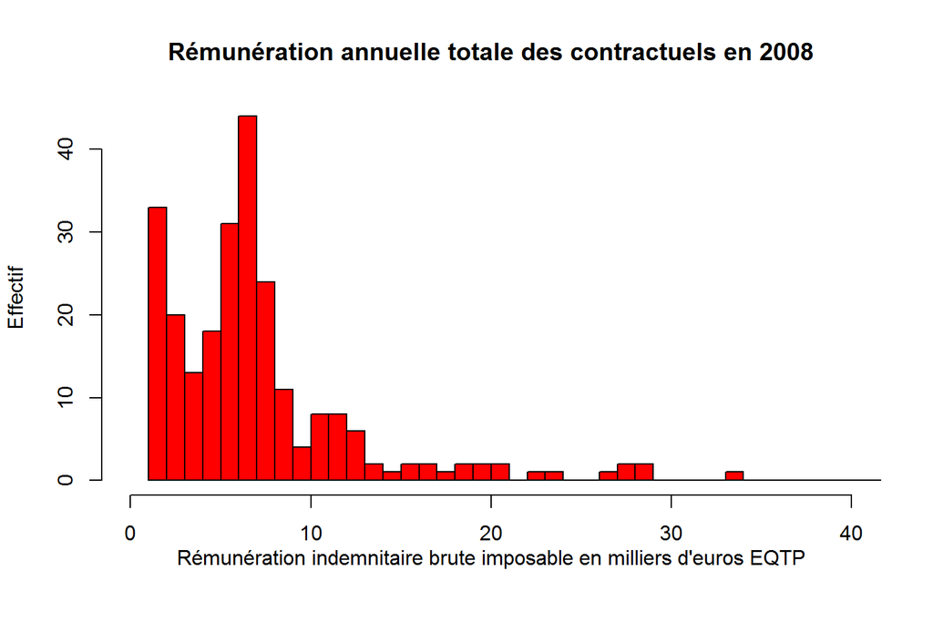

**Nota:** Ne sont retenues que les rémunérations supérieures à 1 000 euros. Les élus ne sont pas pris en compte.

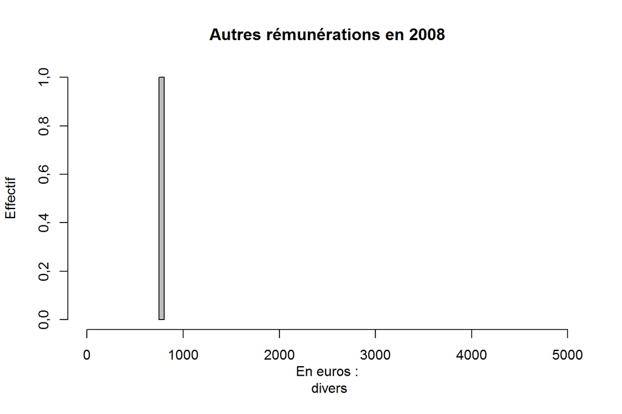

| Statistique | Indemnités imposables | Autres rémunérations | Effectif |
| --- | --- | --- | --- |
| Minimum | 0,0 | 0,000 |  |
| 1er quartile | 484,1 | 0,000 |  |
| Médiane | 2 650,1 | 0,000 |  |
| Moyenne | 4 323,8 | 2,439 | 327 |
| 3ème quartile | 6 269,2 | 0,000 |  |
| Maximum | 42 752,4 | 797,420 |  |

| Statistique | Total rémunérations | Total rémunérations EQTP | Effectif |
| --- | --- | --- | --- |
| Minimum | 0 | 0 |  |
| 1er quartile | 1 619 | 3 663 |  |
| Médiane | 8 795 | 17 207 |  |
| Moyenne | 15 445 | 18 712 | 327 |
| 3ème quartile | 24 792 | 26 661 |  |
| Maximum | 97 650 | 97 383 |  |

# 3. Rémunérations brutes : analyse pour l’exercice 2012

## 3.1 Statistiques de position globales (tous statuts)

### Cumuls des rémunérations brutes pour l’exercice 2012

*Personnels*

| Agrégats | euros |
| --- | --- |
| Brut annuel (bulletins) | 27 545 129 |
| Brut annuel (lignes), dont : | 27 658 590 |
| Indemnités imposables : | 7 170 763 |
| Autres rémunérations | -3 271 |

*Elus*

| Agrégats | euros |
| --- | --- |
| Brut annuel (bulletins) | 706 473 |
| Brut annuel (lignes), dont : | 834 994 |
| Indemnités imposables : | -98 089 |
| Autres rémunérations | 0 |

**Définitions :**

*Brut annuel (bulletins)* : somme du champ *Brut*  
*Brut annuel (lignes)* : somme du champ *Montant* des lignes de paye, dont :  
*Indemnités imposables* : indemnités sauf remboursements, certaines IJSS, indemnités d’élu  
*Indemnités d’élu* : toutes rémunérations indemnitaires des élus  
*Autres rémunérations* : acomptes, retenues sur brut, rémunérations diverses, rappels

**Tests de cohérence**

Somme des rémunérations brutes versées aux personnels (non élus) :

| Agrégats | euros |
| --- | --- |
| Bulletins de paie (euros) | 27 545 129 |
| Lignes de paie (euros) | 27 658 590 |
| Différence (euros) | -113 460 |

à comparer aux soldes des comptes 641 et 648 du compte de gestion.

Somme des rémunérations brutes versées (élus) :

| Agrégats | euros |
| --- | --- |
| Bulletins de paie (euros) | 706 473 |
| Lignes de paie (euros) | 834 994 |
| Différence (euros) | -128 520 |

Les résultats sont exprimés en euros.

## 3.2 Fonctionnaires titulaires et stagiaires

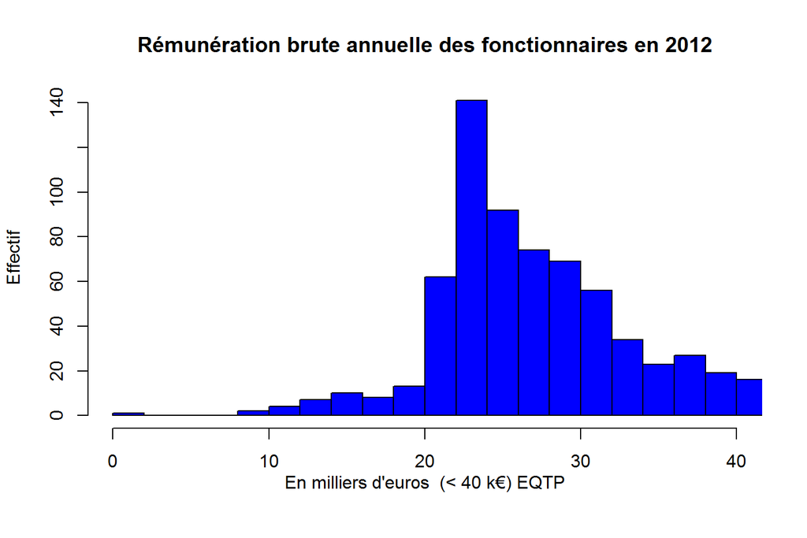

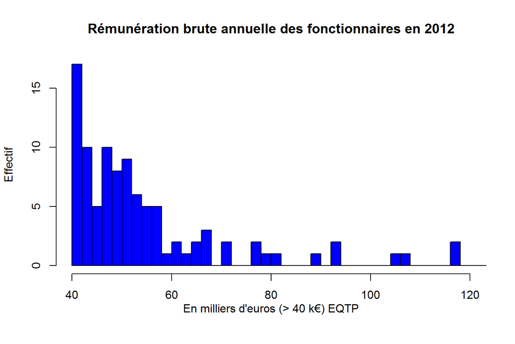

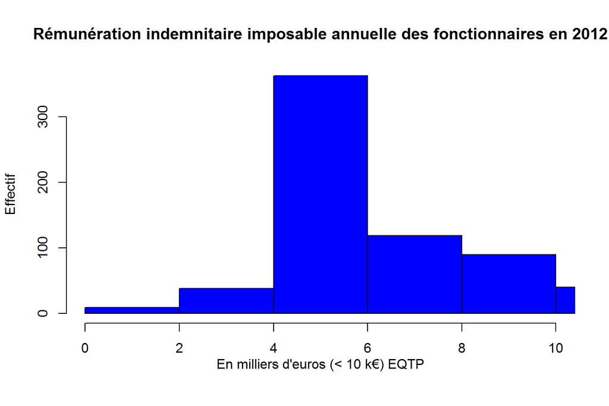

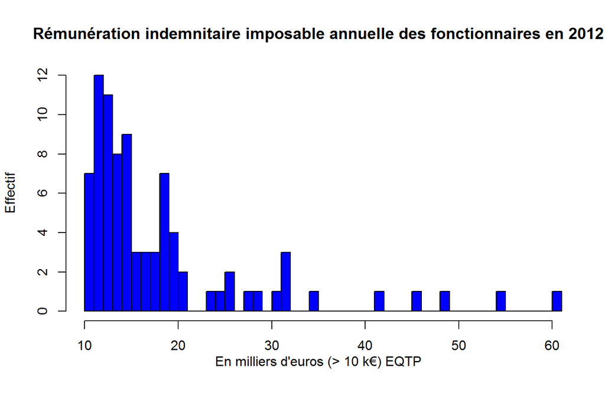

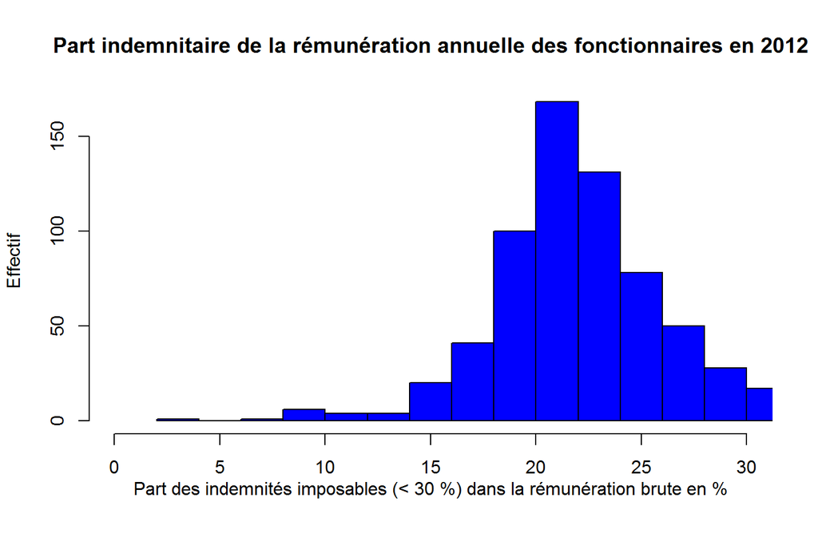

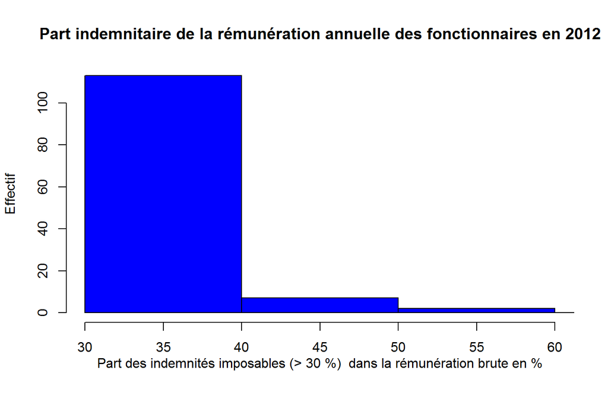

**Effectif : 739**

**Tests de cohérence**

Somme des rémunérations brutes versées aux personnels titulaires et stagiaires :

| Agrégats | euros |
| --- | --- |
| Brut annuel (bulletins) | 20 973 059 |
| Brut annuel (lignes), dont : | 21 062 379 |
| Indemnités imposables : | 5 352 730 |
| Autres rémunérations | -16 669 |

**Définitions :**

*Brut annuel (bulletins)* : somme du champ *Brut* *Brut annuel (lignes)* : somme du champ *Montant* des lignes de paye, dont :  
*Indemnités imposables* : champ *Brut* moins le SFT, le traitement indiciaire et l’indemnité de résidence *Indemnités d’élus* : toutes rémunérations indemnitaires des élus  
*Autres rémunérations* : acomptes, retenues sur brut, rémunérations diverses, rappels

**Tests de cohérence**

Somme des rémunérations brutes versées aux personnels (non élus) :

| Agrégats | euros |
| --- | --- |
| Bulletins de paie (euros) | 20 973 059 |
| Lignes de paie (euros) | 21 062 379 |
| Différence (euros) | -89 319 |

A comparer aux soldes des comptes 6411, 6419 et 648 du conmpte de gestion.

### Statistiques de position pour l’exercice 2012

| Statistique | Traitement indiciaire | Indemnités imposables | Autres rémunérations | Effectif |
| --- | --- | --- | --- | --- |
| Minimum | 0 | -3 695 | -329,58 |  |
| 1er quartile | 17 280 | 4 640 | -54,37 |  |
| Médiane | 19 141 | 5 667 | 0,00 |  |
| Moyenne | 20 679 | 7 243 | -22,56 | 739 |
| 3ème quartile | 23 892 | 8 127 | 0,00 |  |
| Maximum | 54 217 | 107 802 | 69,35 |  |

| Statistique | Total lignes hors rappels | Total brut | Total brut EQTP | Part de la rém. indemnitaire | Effectif |
| --- | --- | --- | --- | --- | --- |
| Minimum | 0 | 121,6 | 1 432 | -31,76 |  |
| 1er quartile | 22 634 | 22 611,4 | 23 120 | 20,08 |  |
| Médiane | 25 937 | 25 942,1 | 26 734 | 22,27 |  |
| Moyenne | 28 577 | 28 457,3 | 29 827 | 24,18 | 737 |
| 3ème quartile | 31 744 | 31 589,3 | 32 811 | 25,89 |  |
| Maximum | 106 703 | 108 054,5 | 117 731 | 100,00 |  |

### Statistiques de position par catégorie pour l’exercice 2012

**Catégorie A**

Pas de statistique en l’absence de fichier des catégories.

**Effectif : 0**

**Catégorie B**

Pas de statistique en l’absence de fichier des catégories.

**Effectif : 0**

**Catégorie C**

Pas de statistique en l’absence de fichier des catégories.

**Effectif : 0**

## 3.3 Contractuels, vacataires et stagiaires inclus

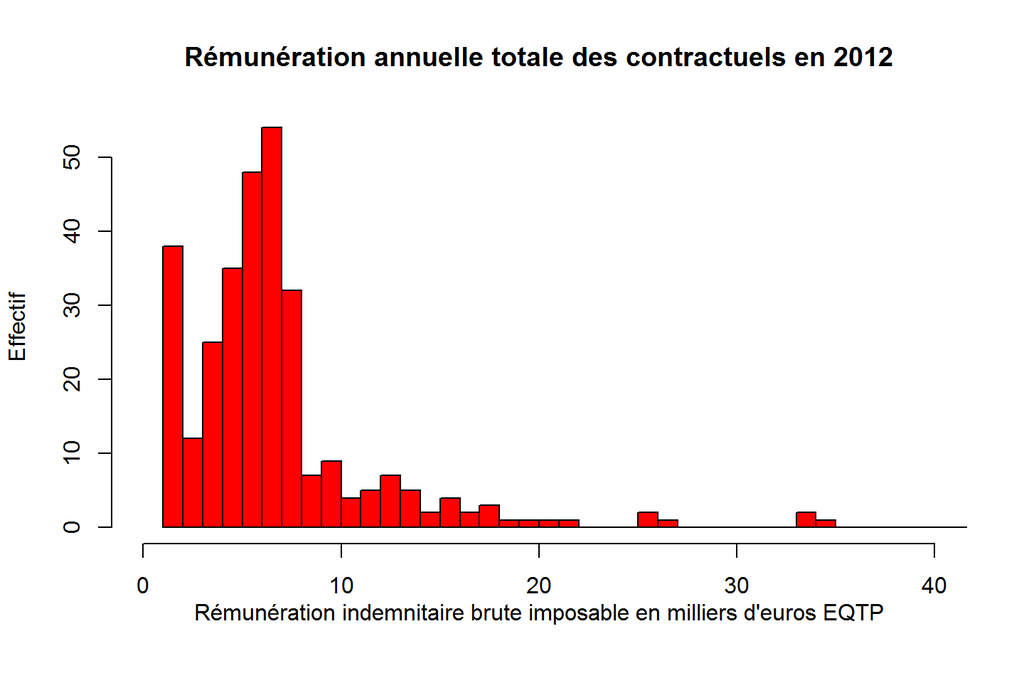

**Nota:** Ne sont retenues que les rémunérations supérieures à 1 000 euros. Les élus ne sont pas pris en compte.

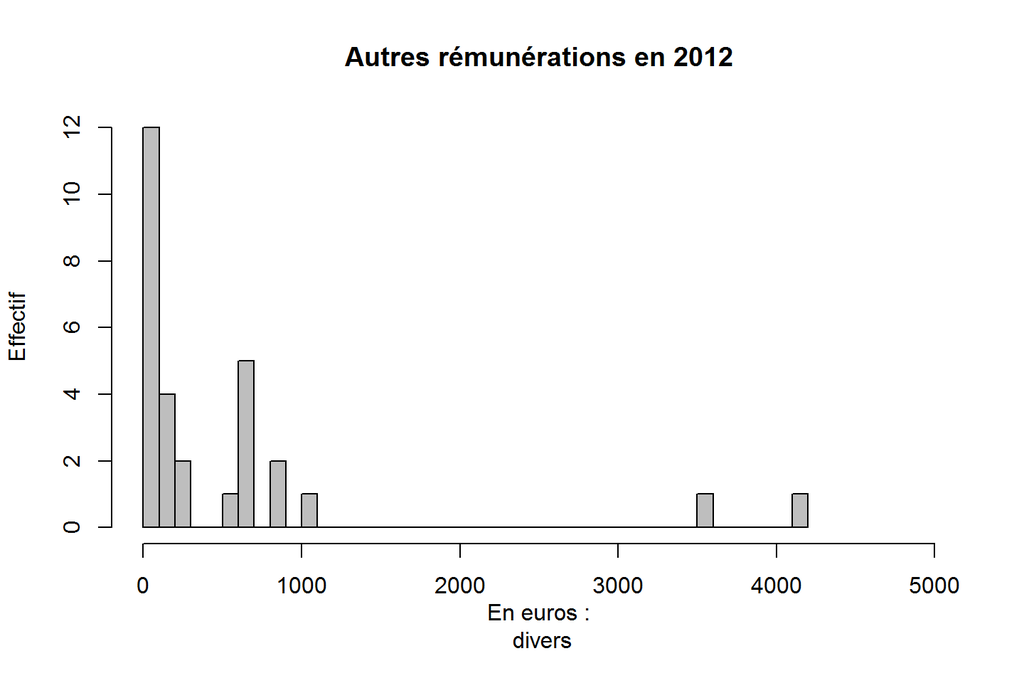

| Statistique | Indemnités imposables | Autres rémunérations | Effectif |
| --- | --- | --- | --- |
| Minimum | -12 862,2 | -162,93 |  |
| 1er quartile | 147,4 | 0,00 |  |
| Médiane | 2 448,1 | 0,00 |  |
| Moyenne | 4 085,5 | 30,11 | 445 |
| 3ème quartile | 6 271,3 | 0,00 |  |
| Maximum | 58 771,7 | 4 115,42 |  |

| Statistique | Total rémunérations | Total rémunérations EQTP | Effectif |
| --- | --- | --- | --- |
| Minimum | -2 780 | -2 772 |  |
| 1er quartile | 1 087 | 4 262 |  |
| Médiane | 10 294 | 18 117 |  |
| Moyenne | 14 769 | 18 132 | 445 |
| 3ème quartile | 22 830 | 24 495 |  |
| Maximum | 130 660 | 130 303 |  |

Lien vers la base de données d’analyse des rémunérations

# 4. Rémunérations nettes : évolutions sur la période 2008 - 2012

Nombre d’exercices: 5

**Les données présentées dans cette section sont toutes relatives à des rémunérations nettes en équivalent temps plein (EQTP)**

## 4.1 Rémunération nette moyenne sur la période

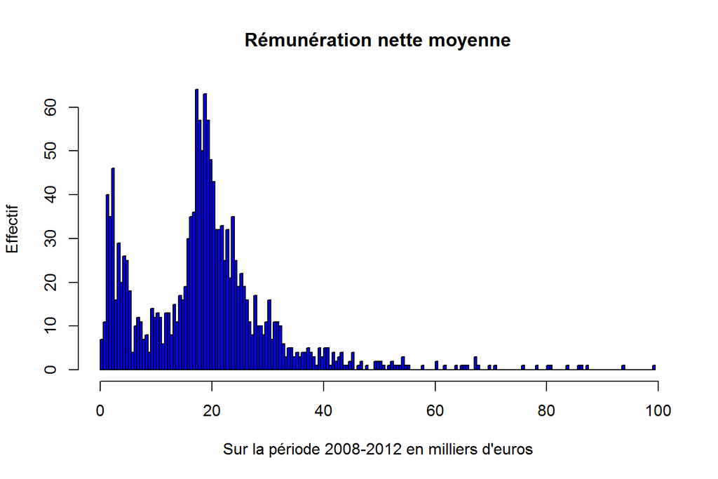

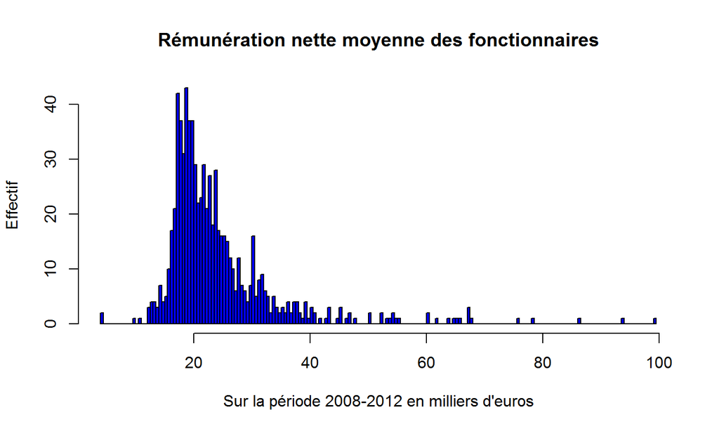

Lien vers la base de données

**Nota:** La rémunération nette perçue est rapportée au cumul des jours d’activité.

## 4.2 Evolutions des rémunérations nettes sur la période 2008 - 2012

### 4.2.1 Ensemble des personnels fonctionnaires et non titulaires

#### Rémunération

| Année | Rémunération nette totale (k€) |
| --- | --- |
| 2008 | 21 357 |
| 2009 | 21 736 |
| 2010 | 22 812 |
| 2011 | 23 716 |
| 2012 | 24 441 |

Lien vers la base de données

| Statistique | Première année | Dernière année | Moyenne sur la période d’activité |
| --- | --- | --- | --- |
| Minimum | -8 812 | -8 812 | -Inf |
| 1er quartile | 14 100 | 13 496 | 14 386 |
| Médiane | 18 620 | 19 227 | 18 991 |
| Moyenne | 19 243 | 19 788 | -Inf |
| 3ème quartile | 23 345 | 24 637 | 24 059 |
| Maximum | 97 669 | 115 721 | 99 442 |

| Statistique | Variation sur la période d’activité (%) | Variation annuelle moyenne (%) | Effectif |
| --- | --- | --- | --- |
| Minimum | -88,672 | -78,1 255 |  |
| 1er quartile | -1,001 | -0,3 963 |  |
| Médiane | 5,118 | 1,4 599 |  |
| Moyenne | 11,008 | 2,9 184 | 1050 |
| 3ème quartile | 12,806 | 3,7 944 |  |
| Maximum | 645,133 | 485,7 520 |  |

| Statistique | Variation normalisée (%) | Variation annuelle moyenne normalisée (%) | Effectif |
| --- | --- | --- | --- |
| Minimum | -83,447 | -36,215 |  |
| 1er quartile | 1,165 | 0,290 |  |
| Médiane | 5,812 | 1,422 |  |
| Moyenne | 7,269 | 1,458 | 619 |
| 3ème quartile | 11,465 | 2,751 |  |
| Maximum | 230,431 | 34,825 |  |

Lien vers la base de données

### 4.2.2 Personnels fonctionnaires et non titulaires en place

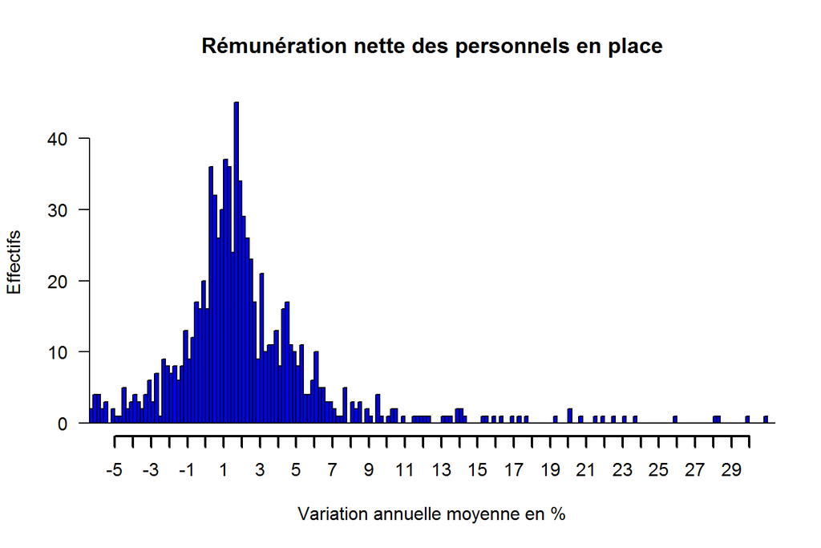

| Année | Rémunération nette totale des agents en place (k€) |
| --- | --- |
| 2008 | 19 293 |
| 2009 | 20 692 |
| 2010 | 22 393 |
| 2011 | 21 981 |
| 2012 | 21 367 |

| Statistique | Première année | Dernière année | Moyenne sur la période d’activité | Effectif |
| --- | --- | --- | --- | --- |
| Minimum | 0 | -2 728 | 284,6 |  |
| 1er quartile | 17 131 | 17 564 | 17 255,0 |  |
| Médiane | 19 663 | 20 156 | 19 953,0 |  |
| Moyenne | 21 007 | 21 845 | 21 755,6 | 1044 |
| 3ème quartile | 24 261 | 25 572 | 25 056,2 |  |
| Maximum | 97 669 | 115 721 | 99 442,2 |  |

| Statistique | Variation sur la période d’activité (%) | Variation annuelle moyenne (%) | Effectif |
| --- | --- | --- | --- |
| Minimum | -88,6 719 | -66,3 428 |  |
| 1er quartile | -0,5 747 | -0,1 863 |  |
| Médiane | 5,3 199 | 1,4 204 |  |
| Moyenne | 11,0 853 | 2,0 809 | 947 |
| 3ème quartile | 12,5 347 | 3,4 774 |  |
| Maximum | 645,1 327 | 162,6 895 |  |

| Statistique | Variation normalisée (%) | Variation annuelle moyenne normalisée (%) | Effectif |
| --- | --- | --- | --- |
| Minimum | -83,447 | -36,215 |  |
| 1er quartile | 1,165 | 0,290 |  |
| Médiane | 5,812 | 1,422 |  |
| Moyenne | 7,269 | 1,458 | 619 |
| 3ème quartile | 11,465 | 2,751 |  |
| Maximum | 230,431 | 34,825 |  |

Lien vers la base de données

**Nota** Personnels en place : en fonction au moins 730 jours sur la période 2008 à 2012

### 4.2.3 Personnels fonctionnaires et non titulaires en fonction moins de deux ans

| Année | Rémunération nette totale des agents en fonction moins de deux ans (k€) |
| --- | --- |
| 2008 | 2 063,6 |
| 2009 | 1 043,6 |
| 2010 | 419,3 |
| 2011 | 1 734,4 |
| 2012 | 3 074 |

| Statistique | Première année | Dernière année | Moyenne sur la période d’activité | Effectif |
| --- | --- | --- | --- | --- |
| Minimum | -8 812 | -8 812 | -Inf |  |
| 1er quartile | 4 491 | 4 475 | 4 470 |  |
| Médiane | 13 831 | 13 552 | 13 653 |  |
| Moyenne | 14 686 | 14 472 | -Inf | 404 |
| 3ème quartile | 20 097 | 20 193 | 19 780 |  |
| Maximum | 94 598 | 92 957 | 93 778 |  |

| Statistique | Variation sur la période d’activité (%) | Variation annuelle moyenne (%) | Effectif |
| --- | --- | --- | --- |
| Minimum | -78,126 | -78,126 |  |
| 1er quartile | -11,807 | -11,807 |  |
| Médiane | 2,787 | 2,787 |  |
| Moyenne | 10,294 | 10,619 | 103 |
| 3ème quartile | 15,177 | 14,201 |  |
| Maximum | 485,752 | 485,752 |  |

Lien vers la base de données

**Nota:** Au 4.2 seuls sont pris en compte les personnels en fonction au moins 100 jours la première et la dernière année Ne sont pas pris en compte les élus, stagiaires et apprentis ou assimilés.

Les résultats sont exprimés en euros.

# 5. Tests réglementaires

## 5.1 Contrôle des heures supplémentaires, des NBI et primes informatiques

Primes informatiques potentielles : aucune

| Nombre de lignes NBI pour non titulaires | Nombre de bénéficiaires de PFI |
| --- | --- |
| 0 | 0 |

Lien vers la base de données NBI aux non titulaires Lien vers la base de données Primes informatiques

**Nota :** NBI: nouvelle bonification indiciaire PFI: prime de fonctions informatiques

## 5.2 Contrôle des vacations pour les fonctionnaires

| Nombre de FEV | Nombre de lignes de vacations pour FEV |
| --- | --- |
| 0 | 0 |

Lien vers la base de données Matricules des FEV Lien vers la base de données Lignes de vacations de FEV

**Nota:** FEV : fonctionnaire effectuant des vacations

## 5.3 Contrôles sur les cumuls traitement indiciaire, indemnités et vacations des contractuels

**Contractuels effectuant des vacations (CEV)**

| Nombre de CEV | Nombre de lignes | Nombre de lignes indemnitaires | Nombre de lignes de traitement |
| --- | --- | --- | --- |
| 0 | 0 | 0 | 0 |

Lien vers la base de données Matricules des CEV Lien vers la base de données Lignes de paie de CEV Lien vers la base de données Lignes de traitement indiciaire pour CEV

## 5.4 Contrôle sur les indemnités IAT et IFTS

| Codes IFTS | Nombre de personnels percevant IAT et IFTS |
| --- | --- |
| 202A 202N 202R 502A 502N 502R 502V | 47 |

Codes IFTS retenus Lien vers la base de données

### Contrôle sur les IFTS pour catégories B et contractuels

| Nombre de contractuels percevant des IFTS | Nombre de lignes IFTS pour IB < 380 |
| --- | --- |
| 2 448 | 318 |

Lien vers la base de données Lignes IFTS pour contractuels Lien vers la base de données Lignes IFTS pour IB < 380

**Nota:** IB < 380 : fonctionnaire percevant un indice brut inférieur à 380

## 5.5 Contrôle sur les heures supplémentaires

| Nombre de lignes HS en excès | Nombre de lignes IHTS anormales |
| --- | --- |
| 2 756 | 0 |

Lien vers la base de données Heures suplémentaires en excès : matricules Lien vers la base de données IHTS anormales

**Nota:** HS en excès : au-delà de 25 heures par mois IHTS anormales : non attribuées à des fonctionnaires de catégorie B ou C.

## 5.6 Contrôle sur les indemnités des élus

| Matricule | Nom | Année | Emploi | Indemnités (euros) | Autres (euros) | Total (euros) |
| --- | --- | --- | --- | --- | --- | --- |
| 1002 P | XXXX | 2008 | CONSEILLER COMMUNAUTAIRE | 2301,44 | 0 | 2443,61 |
| 1002 P | XXXX | 2009 | CONSEILLER COMMUNAUTAIRE | 2710,56 | 0 | 2710,56 |
| 1002 P | XXXX | 2010 | CONSEILLER COMMUNAUTAIRE | 2730,24 | 0 | 2730,24 |
| 1002 P | XXXX | 2011 | CONSEILLER COMMUNAUTAIRE | 2737,08 | 0 | 2737,08 |
| 1002 P | XXXXX | 2012 | CONSEILLER COMMUNAUTAIRE | 2737,08 | 0 | 2737,08 |
| etc... | etc... | etc... | etc... | etc... | etc... | etc... |

Lien vers la base de données Rémunérations des élus

# Annexe

## Liens complémentaires

Lien vers la base de données fusionnées des bulletins et lignes de paie

Lien vers le fichier des personnels

# Tableau des personnels : renseigner la catégorie

Utiliser les codes : A, B, C, ELU, AUTRES

En cas de changement de catégorie en cours de période, utiliser la catégorie AUTRES Cela peut conduire à modifier manuellement le fichier Catégories des personnels.csv